# **SI 618 - Homework #1: Dive into Data Manipulation**

*Version 2024.09.05.2.CT*

Welcome to your first homework assignment for **SI 618**! In this task, you'll explore the fundamentals of data manipulation, using real-world datasets to practice essential skills. Get ready to dive deep, solve some fun challenges, and level up your data wrangling game!

## **Background**

In this assignment, we’ll dive into some exciting **biometric data** and explore how exercise performance relates to key health metrics. 🚶‍♂️💪

### Your Task:

- You'll apply **data manipulation techniques** we've learned in class and from the readings.
- Feel free to consult resources like:
  - [**pandas documentation**](https://pandas.pydata.org/pandas-docs/stable/) 📘
  - [**Stack Overflow**](https://stackoverflow.com/) 🌐
  - [**Copilot**](https://github.com/features/copilot) (for code suggestions)

Remember, the goal is to practice **real-world problem-solving** using data manipulation skills, so explore, test, and have fun with the data!

### Scoring and Guidelines

This assignment is worth a **total of 100 points**, with the breakdown of points shown beside each question. Please refer to the accompanying rubric on Canvas for more details.

To earn **full points**, ensure the following:

- Your code should conform to the [**PEP 8**](https://www.python.org/dev/peps/pep-0008/) style guidelines for Python. 🐍
- Written responses should be:
  - **Grammatically correct** and free of spelling errors.
  - Following the [**Strunk & White**](https://drive.google.com/file/d/1L0P7xJwjUGBvyb49mL3dw1Bt7hzRTiTl/view) guidelines for clear and effective writing.

### Code Structure

- **Wrap your code in functions** wherever possible! This will make your code reusable for future assignments. 🔁
- Don't forget to include:
  - **Comments** (explain your thought process),
  - **Docstrings** (describe your functions), and
  - **Type hints** (specify the data types).

💡 **Reminder**: Undocumented code **will not** receive full credit.

### Important Notes for Submission

- **Add as many cells as you need** to complete your work.
- Use:
  - **"Code" cells** for writing your Python code, and
  - **"Markdown" cells** for explanations, interpretations, and write-ups.

📝 **Pro tip**: After each question, insert new cells for your solutions and explanations!

⚠️ **Note**: Please **do not remove** any of the existing cells in the notebook.

## 📝 Answer the Following Questions

Each question is worth a certain number of points, indicated beside the question.

🔢 **Tip**: Make sure to provide detailed answers, and don't hesitate to use extra cells for your code and explanations!

### 🟢 Q1: Data Exploration with pandas (10 pts)

This question focuses on writing code and exploring a pandas DataFrame. Note: **Biometric data is not required for this question.**

#### 🔹 Q1a (2pt):

List **5 methods or attributes** that can be used to explore a pandas DataFrame or Series. For each method/attribute, explain:

- What it does, and
- How it can help explore the data.

Make sure to write **complete sentences** for your explanations.

#### 🔹 Q1b (4pt):

Write a function to generate a **pandas DataFrame** with the following parameters:

1. **Number of rows**: The number of rows for the DataFrame.
2. **Number of columns**: The number of columns for the DataFrame
3. **Optional column names**: A list of column names (if not provided, default to integers starting from 0 up to number_of_columns - 1).
4. **Optional row index values**: A list of row index values (if not provided, default to integers starting from 0 up to number_of_rows - 1).
5. **Optional random seed**: default = 12345

#### Example - DataFrame

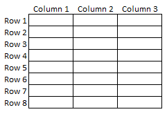

The DataFrame should be filled with **random values** between -1 and 1.

#### 🔹 Q1c (4pt):

Use the function you created to make a DataFrame with:

- Columns: `['a', 'b', 'c']`
- Index: `['x', 'y', 'z']`

Apply the **5 methods/attributes** you listed in Q1a to explore this DataFrame. For each method, write a short explanation of what you learned from it.

#### 🔹 Q1a

- shape It is an attribute for dataframe to describe the number of rows and columns.
- describe() The method generates summary statistics (like mean, median, etc).
- column It is used to present columnn name for dataframe
- index It is used to present index for dataframe
- drop() The method drops specific columns or rows from dataframe

```python
import pandas as pd
import numpy as np

def generate_df (row_num, col_num, col_name = None, row_index = None, seed = 12345):
    '''
    Generate a dataframe with you defined the number of columns and rows and the name of columns and rows, which
    element is randomly generated between -1 and 1.
    '''
    np.random.seed(seed)
    data = np.random.uniform(-1,1,(row_num, col_num))
    if col_name == None:
        col_name = [i for i in range(col_num)]
    if row_index == None:
        row_index ==[i for i in range(row_num)]

    df = pd.DataFrame(data, columns = col_name, index = row_index)
    return df
print(generate_df(8, 3, ['Column 1', 'Column 2', 'Column 3'], ['Row 1', 'Row 2', 'Row 3','Row 4','Row 5','Row 6','Row 7','Row 8']))
```

```
       Column 1  Column 2  Column 3
Row 1  0.859232 -0.367249 -0.632162
Row 2 -0.590879  0.135450  0.191089
Row 3  0.929029  0.306354  0.497813
Row 4  0.307140  0.495430  0.922613
Row 5 -0.983223 -0.787111 -0.402593
Row 6  0.312822  0.619625  0.744352
Row 7  0.929295  0.447371  0.284951
Row 8  0.434907 -0.064802 -0.348831
```

```python
df_c = generate_df(3, 3, ['a', 'b', 'c'], ['x', 'y', 'z'])
```

```python
print(df_c.shape)
#return dataframe dimension. The dataframe is 3 rows and 3 columns.
```

```
(3, 3)
```

```python
print(df_c.describe())
#return dataframe statistical attributes for each column. The mean of a is 0.39. b is 0.02, c is 0.02.
```

```
              a         b         c
count  3.000000  3.000000  3.000000
mean   0.399127  0.024852  0.018913
std    0.858081  0.350156  0.584333
min   -0.590879 -0.367249 -0.632162
25%    0.134176 -0.115899 -0.220536
50%    0.859232  0.135450  0.191089
75%    0.894131  0.220902  0.344451
max    0.929029  0.306354  0.497813
```

```python
print(df_c.columns)
#return the name of columns.The names of columns are a, b, c.
```

```
Index(['a', 'b', 'c'], dtype='object')
```

```python
print(df_c.index)
#return row index. The indexes of rows are x, y, z.
```

```
Index(['x', 'y', 'z'], dtype='object')
```

```python
print(df_c.drop('a', axis = 1))
#drop the column a temporarily. Drop the column a.
```

```
          b         c
x -0.367249 -0.632162
y  0.135450  0.191089
z  0.306354  0.497813
```

## 📥 Download the Data

Please download the dataset from the following link:  
[**Kaggle: Body Performance Data**](https://www.kaggle.com/kukuroo3/body-performance-data)

💡 **Tip**: Make sure you're logged into your Kaggle account before downloading.

### 🟢 Q2: Median Statistics (5 pt)

Implement a function to calculate the **median age, height, and weight** of individuals in the dataset, **without** using `pd.DataFrame.describe()`.

- **Rounding**: Round the results to the nearest whole number.
- **Units**: Be sure to indicate the units for each variable in your write-up.

#### 🔹 Summary:

Write 1-2 sentences summarizing the output of your function, clearly stating the median values for age, height, and weight, and mentioning the units.

```python
# your code goes here
body_perform = pd.read_csv("../data/bodyPerformance.csv")
def median_age_height_weight(dataframe):
    '''
    input a dataframe with header of age, height_cm, weight_kg
    return a dataframe with median of age, height_cm, weight_kg
    '''
    #obtain the original header of height and weight with units in case their units are different
    height_header = [i for i in dataframe.columns if 'height' in i][0]
    weight_header = [i for i in dataframe.columns if 'weight' in i][0]
    age_median = round(dataframe.age.median(),0)
    height_median = round(dataframe.height_cm.median(),0)
    weight_median = round(dataframe.weight_kg.median(),0)
    output = {
        'age_median': age_median,
        f'{height_header}_median': height_median,
        f'{weight_header}_median': weight_median
    }
    return pd.DataFrame([output])

median_age_height_weight(body_perform)
```

|  | age_median | height_cm_median | weight_kg_median |
| --- | --- | --- | --- |
| 0 | 32.0 | 169.0 | 67.0 |

In the dataset, the median of age is 32 years old. The median of height in is 169 cm. The median of weight is 67 kg.

### 🟢 Q3: Detecting Anomalies (5 pt)

Investigate the dataset for **anomalous data points**. Consider the following example:

- **Diastolic blood pressure** being higher than **systolic blood pressure** is physiologically impossible.

But don’t stop there! 🚩 Explore the data for other potential anomalies as well.

Think about the following as you attempt the next task

- Logical Indexing / Boolean Indexing
- Filter using quantile values

#### 🔹 Task:

- Identify any other types of anomalies that might exist.
- Write 1-2 sentences summarizing your findings and insights from the data.

💡 **Hint**: Think about physiologically or statistically unusual values in the dataset.

```python
body_perform_normal = body_perform[body_perform['diastolic'] <= body_perform['systolic']]

body_perform_normal.count()
```

```
age                        13389
gender                     13389
height_cm                  13389
weight_kg                  13389
body fat_%                 13389
diastolic                  13389
systolic                   13389
gripForce                  13389
sit and bend forward_cm    13389
sit-ups counts             13389
broad jump_cm              13389
class                      13389
dtype: int64
```

I drop the obs whose diastolic > systolic. For percentile, I think it all makes sense so I don't drop. If the age is 65, then it makes sense the old man cannot do sit-up and the count euqals to 0.

### 🟢 Q4: Visualizing Age, Weight, and Height (10 pt)

Your task is to generate **histogram plots** to visualize the differences in **age, weight, and height** between gender M and gender F participants.

#### 🔹 Instructions:

- Create the histograms using **only** the **matplotlib-pandas** integration (you cannot use Seaborn, Bokeh, or Plotly).
- After generating the plots, write a brief description of each, pointing out any interesting observations or patterns you notice.

💡 **Hint**: Look for differences in distribution, outliers, or trends between the genders.

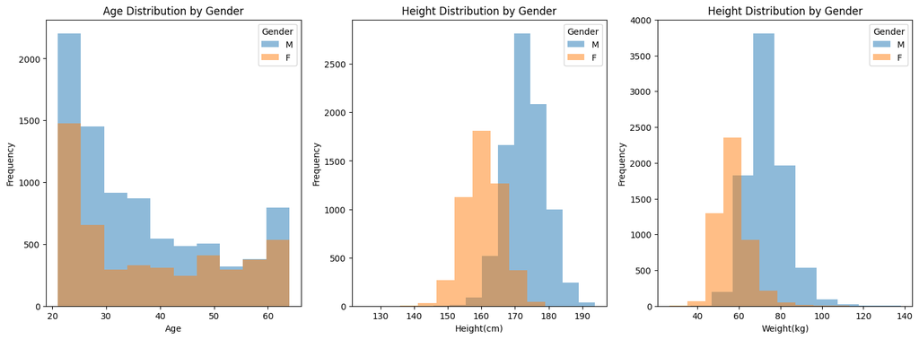

```python
import matplotlib.pyplot as plt
# Set up the matplotlib figure
plt.figure(figsize=(18, 6))

plt.subplot(1, 3, 1)

for gender in body_perform_normal.gender.unique():
    subset = body_perform_normal[body_perform_normal['gender']==gender]
    plt.hist(subset['age'], bins = 10, alpha = 0.5, label = gender)
plt.title("Age Distribution by Gender")
plt.xlabel("Age")
plt.ylabel('Frequency')
plt.legend(title = 'Gender')

plt.subplot(1, 3, 2)
for gender in body_perform_normal.gender.unique():
    subset = body_perform_normal[body_perform_normal['gender']==gender]
    plt.hist(subset['height_cm'], bins = 10, alpha = 0.5, label = gender)
plt.title("Height Distribution by Gender")
plt.xlabel("Height(cm)")
plt.ylabel('Frequency')
plt.legend(title = 'Gender')

plt.subplot(1, 3, 3)
for gender in body_perform_normal.gender.unique():
    subset = body_perform_normal[body_perform_normal['gender']==gender]
    plt.hist(subset['weight_kg'], bins = 10, alpha = 0.5, label = gender)
plt.title("Height Distribution by Gender")
plt.xlabel("Weight(kg)")
plt.ylabel('Frequency')
plt.legend(title = 'Gender')
```

1. Female population in the survey is less than male population so it is common to find frequency of female each part is less than male.
2. The median of female is about 160 cm, which is appropriate, while the median of male is about 175 cm. The mode of female and male is roughly same as median.
3. For both female and male, each distribution of height and weight is all similar to normal distribution.

### 🟢 Q5: Understanding Blood Pressure Categories (15 pt)

#### Background:

Blood pressure is measured using two numbers:

- **Systolic** (the upper number)
- **Diastolic** (the lower number)

For example, a blood pressure of **120/80** means the systolic pressure is **120 mm Hg** and the diastolic pressure is **80 mm Hg**. Blood pressure readings are important for identifying heart health and are classified into several categories. Here’s a quick summary of the categories:

| Category | Systolic (mm Hg) | Diastolic (mm Hg) |
| --- | --- | --- |
| **Normal** | Below 120 | Below 80 |
| **Elevated** | 120-129 | Below 80 |
| **Stage 1 Hypertension** | 130-139 | 80-89 |
| **Stage 2 Hypertension** | 140 or higher | 90 or higher |
| **Hypertensive Crisis** | Higher than 180 | Higher than 120 |

#### 🔹 Task:

**Part A (8 pt):**  
Using the categories above, report the **number of people** who fall into each blood pressure category in the dataset.

**Part B (7 pt):**  
In 2017, the blood pressure guidelines changed:

- **Before 2017**, hypertension was defined as a systolic pressure of **140 mm Hg** or more for people younger than 65, and **150 mm Hg** or more for those aged 65 and older.
- **After 2017**, hypertension is defined at a lower level (starting at 130/80 mm Hg).

#### Your Job:

1. Analyze how the **change in guidelines** affects the classification of individuals.
   - For example: how many people were considered hypertensive before 2017, and how many are classified as hypertensive after the change?
2. Make reasonable assumptions about how to use systolic and diastolic pressures for your analysis. Clearly state these assumptions in your write-up.

💡 **Hint**: Consider analyzing the data for different age groups (<65 and 65+), and decide whether to base your categorization on systolic, diastolic, or both measures.

#### 🔹 Summary:

- Clearly report the number of people in each category.
- Discuss how the new guidelines (post-2017) affect the classification compared to the old guidelines. Blood pressure measurements fall into several categories:

**Normal Blood Pressure** - Your blood pressure is normal if it's below 120/80 mm Hg.

**Elevated Blood Pressure** - Elevated blood pressure is a systolic pressure ranging from 120 to 129 mm Hg and a diastolic pressure below (not above) 80 mm Hg. Elevated blood pressure may also be called prehypertension.

**Stage 1 Hypertension** - Stage 1 hypertension is a systolic pressure ranging from 130 to 139 mm Hg or a diastolic pressure ranging from 80 to 89 mm Hg.

**Stage 2 Hypertension** - More-severe hypertension, stage 2 hypertension is a systolic pressure of 140 mm Hg or higher or a diastolic pressure of 90 mm Hg or higher.

**Hypertensive Crisis** - A blood pressure measurement higher than 180/120 mm Hg is an emergency situation that requires urgent medical care.

a) Report the number of people in each of those categories.

b) The guidelines were recently changed: prior to 2017, the guidelines set the threshold at 140/90 mm Hg for people younger than age 65 and 150/80 mm Hg for those ages 65 and older to be diagnosed with hypertension. Create and implement analyses that allow you to demonstrate how the change in guidelines affects the categorization of people into the different categories. Make reasonable assumptions (and state them) about whether to use diastolic, systolic, both, or either of those measures when implementing your analysis. Note that the new guidelines offer more categories than the older guidelines.

```python
# Part A
conditions = [(body_perform_normal['diastolic']<80)&(body_perform_normal['systolic']<120),
             (body_perform_normal['diastolic']<80)&(120<=body_perform_normal['systolic'])&(body_perform_normal['systolic']<=129),
             (body_perform_normal['diastolic']<=89)&(80<=body_perform_normal['diastolic'])&(body_perform_normal['systolic']>=130)&(body_perform_normal['systolic']<=139),
             (body_perform_normal['diastolic']>=90)&(body_perform_normal['diastolic']<=119)&(body_perform_normal['systolic']>=140)&(body_perform_normal['systolic']<=179),
             (body_perform_normal['diastolic']>=120)&(body_perform_normal['systolic']>=180)
]
choices= ['Normal', 'Elevated', 'Stage 1 Hypertension', 'Stage 2 Hypertension', 'Hypertensive Crisis']
body_perform_normal['blood_pressure_category'] = np.select(conditions, choices, default = 'Unknown')
body_perform_normal['blood_pressure_category'].value_counts()
```

```
blood_pressure_category
Unknown                 5430
Normal                  2896
Elevated                2090
Stage 2 Hypertension    1676
Stage 1 Hypertension    1296
Hypertensive Crisis        1
Name: count, dtype: int64
```

- Some unknown situations come up since the diastolic and systolic are simultaneuously constrained. For example, when body_perform['diastolic']<80 and body_perform['systolic']>=130, it is not classfied into given category.
- For given category, the normal is most common. Most of us are good in this way.
- However, the totle number of the categories related to hypertension are actually more than normal. It is a dangerous signal.
- What's more, stage 2 hypertension is higher frequence than stage 1. It warns us that we have to test our blood pressure often in case we miss the best time to be cured.

Assumption:

- After changing guidline, more hypertension patients will be identified before 65. So they can be treated early.
- Besides age, lowering teh standards for hypertension will also make more people aware of their poor health condition, allowing treatment to be prioritized and enabling more people to receive timely treatment before their hypertension progresses to type 2 or more severe situation.

```python
#Part B
before_condition = [(body_perform_normal['systolic']>=140) & (body_perform_normal['age']<65) |
                    (body_perform_normal['systolic']>=150) & (body_perform_normal['age']>=65)
]
after_condition = [(body_perform_normal['systolic']>=130) & (body_perform_normal['diastolic']>=80)]
body_perform_normal["before_hypertension"] = np.select(before_condition, 'Y', default = 'N')
body_perform_normal['after_hypertension'] = np.select(after_condition, 'Y', default = 'N')
hypertension_after = body_perform_normal.groupby(['after_hypertension']).size()
hypertension_before = body_perform_normal.groupby(['before_hypertension']).size()
print(hypertension_after)
print(hypertension_before)
```

```
after_hypertension
N    8455
Y    4934
dtype: int64
before_hypertension
N    9626
Y    3763
dtype: int64
```

Assumption 2 has been proved by code above cuz the number of hypertention patient is more than before.

```python
#65 or more
after_65 = body_perform_normal[body_perform_normal['age']>=65]
before_65 = body_perform_normal[body_perform_normal['age']>=65].groupby('before_hypertension').size()
print(after_65)
print(body_perform_normal['age'].max())
# hypenrtension_65 = pd.merge(after_65, before_65, on = 'Hypertension_Status', how = 'outer')
#55-65
after_55 = body_perform_normal[(body_perform_normal['age']<=65) & (body_perform_normal['age']>=55)].groupby('after_hypertension').size().reset_index(name='Count').rename(columns={'after_hypertension': 'Hypertension_Status', 'Count': 'Count_After'})
before_55 = body_perform_normal[(body_perform_normal['age']<=65) & (body_perform_normal['age']>=55)].groupby('before_hypertension').size().reset_index(name='Count').rename(columns={'before_hypertension': 'Hypertension_Status', 'Count': 'Count_Before'})
hypenrtension_55 = pd.merge(after_55, before_55, on = 'Hypertension_Status', how = 'outer')
#less than 55
after_younger = body_perform_normal[body_perform_normal['age']<55].groupby('after_hypertension').size().reset_index(name='Count').rename(columns={'after_hypertension': 'Hypertension_Status', 'Count': 'Count_After'})
before_younger = body_perform_normal[body_perform_normal['age']<55].groupby('before_hypertension').size().reset_index(name='Count').rename(columns={'before_hypertension': 'Hypertension_Status', 'Count': 'Count_Before'})
hypenrtension_younger = pd.merge(after_younger, before_younger, on = 'Hypertension_Status', how = 'outer')
print(hypenrtension_55)
print(hypenrtension_younger)
```

```
Empty DataFrame
Columns: [age, gender, height_cm, weight_kg, body fat_%, diastolic, systolic, gripForce, sit and bend forward_cm, sit-ups counts, broad jump_cm, class, blood_pressure_category, before_hypertension, after_hypertension]
Index: []
64.0
  Hypertension_Status  Count_After  Count_Before
0                   N         1188          1262
1                   Y         1079          1005
  Hypertension_Status  Count_After  Count_Before
0                   N         7267          8364
1                   Y         3855          2758
```

The max of dataset is 64, so we choose 55 as a high level age to compare. Since the percentage of hypertension old man is slightly increasing by 3% but the younger group's percentage increases by 10%. Assumption 2 is proved.

### 🟢 Q6: Creating Age Categories and Analyzing Sit-Ups (10 pt)

Your task is to create a new variable called **"age_class"** that groups people into the following categories:

- **"early"**: Age < 40
- **"middle"**: Age between 40 and 60 (inclusive)
- **"late"**: Age > 60

#### 🔹 Steps:

1. Create the **"age_class"** variable based on the conditions above.
2. For each age group ("early", "middle", "late"):
   - Report the **mean** number of sit-ups performed.
   - Report the **median** number of sit-ups performed.

💡 **Hint**: Make sure to check your code for correctness by verifying the results for a few random individuals in the dataset.

```python
condition_age = [body_perform_normal['age']<40, (body_perform_normal['age']<=60) & (body_perform_normal['age']>=40),
                 body_perform_normal['age']>60]
label_age =['early', 'middle', 'late']
body_perform_normal['age_class'] = np.select(condition_age, label_age, default='unknown')
agg_age_class = body_perform_normal.groupby("age_class").agg({
    'sit-ups counts': ['mean', 'median']
})
print(agg_age_class)
```

```
          sit-ups counts
                    mean median
age_class
early          45.302166   47.0
late           24.060166   25.0
middle         31.815141   32.0
```

### 🟢 Q7: Calculating and Visualizing BMI (15 pt)

#### 🔹 Part A: Calculating BMI

You’ll need to implement a function to calculate each person's **Body Mass Index (BMI)** using the following formula:

- **BMI formula (metric system)**:

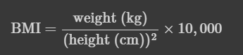

1. Write a function that accepts **weight (kg)** and **height (cm)** as parameters and returns the **BMI**.
2. Use this function to create a new column in your DataFrame called **'BMI'**.

💡 **Note**: The CDC provides a detailed explanation of BMI calculation, which you can refer to [here](https://www.cdc.gov/nccdphp/dnpao/growthcharts/training/bmiage/page5_1.html).

#### 🔹 Part B: Visualizing BMI

Once you’ve added the BMI values to your DataFrame, create two histograms of the BMI using the **pandas-matplotlib integration**:

- One histogram for **gender F**.
- One histogram for **gender M**.

#### 🔹 Part C: Analysis

Compare the two histograms and describe:

- Any **similarities** in the distributions.
- Any **differences** between gender F and gender M.

💡 **Hint**: Think about aspects like the **shape of the distribution**, the **spread of BMI values**, and any **outliers** in the data.

```python
# Part A
def BMI(dataframe: pd.DataFrame, weight_kg: str, height_cm: str) -> pd.Series:
    return dataframe[weight_kg]/(dataframe[height_cm]*dataframe[height_cm])*10000

body_perform_normal['BMI'] = BMI(body_perform_normal,'weight_kg','height_cm')
print(body_perform_normal.BMI)
```

```
0        25.344179
1        20.495868
2        24.181428
3        23.349562
4        22.412439
           ...
13388    24.241679
13389    19.788128
13390    25.637073
13391    27.031826
13392    24.576145
Name: BMI, Length: 13389, dtype: float64
```

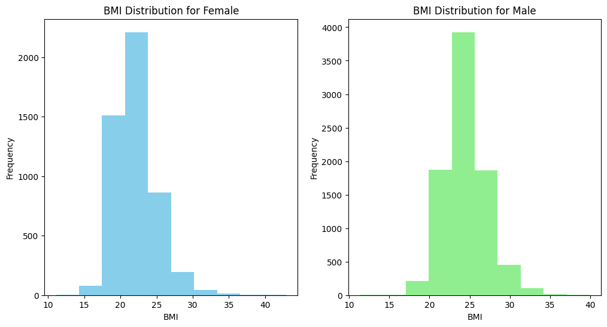

```python
# Part B
plt.figure(figsize = (12, 6))
plt.subplot(1, 2, 1)
subset_f = body_perform_normal[body_perform_normal['gender']=='F']
plt.hist(subset_f['BMI'], bins=10, label = 'female', color = 'skyblue')
plt.title("BMI Distribution for Female")
plt.xlabel("BMI")
plt.ylabel("Frequency")
plt.subplot(1, 2, 2)
subset_m = body_perform_normal[body_perform_normal['gender']=='M']
plt.hist(subset_m['BMI'], bins=10, label = 'male', color = '#90EE90')
plt.title("BMI Distribution for Male")
plt.xlabel("BMI")
plt.ylabel("Frequency")
```

Part C: Similarities:

1. They both seems like normal distriburtion. Differences:
2. The mode and median of BMI for female is smaller than male's.
3. The number of female is fess than male.

### 🟢 Q8: Comparing Health Metrics by Gender (12 pt)

Your task is to compare the **mean values** of the following health metrics between **gender F** and **gender M**:

- **Height** (cm)
- **Weight** (kg)
- **Body fat %**
- **Grip force** (kg)
- **Sit and bend forward** (cm)
- **Sit-ups count** (reps)

#### 🔹 Steps:

1. **Quantitative Analysis**:
   - Use pandas to calculate the **mean values** for each metric for both gender F and gender M.
   - Make sure to include the **units** for each metric in your summary.
2. **Visual Analysis**:
   - Create visualizations (e.g., bar plots, histograms) to compare the distribution of these metrics between the two genders. Use **matplotlib** to generate these plots.
3. **Functionality**:
   - Where possible, implement **functions** to perform these comparisons (e.g., a function that calculates mean values for each gender).

#### 🔹 Summary:

Write a brief summary of your findings, discussing:

- The differences in the mean values between gender F and gender M.
- Any interesting observations or patterns you notice in the visualizations.
- Ensure you mention the **units** for each metric in your write-up.

```python
gender_groupby = body_perform_normal.groupby('gender').agg({
    "height_cm": "mean",
    "weight_kg": "mean",
    "body fat_%": 'mean',
    "gripForce": 'mean',
    "sit and bend forward_cm": 'mean',
    "sit-ups counts": 'mean'
})
print(gender_groupby)
```

```
         height_cm  weight_kg  body fat_%  gripForce  sit and bend forward_cm  \
gender
F       160.486274  56.906733   28.486143  25.818830                18.838093
M       173.258046  73.579672   20.188785  43.446783                13.096139

        sit-ups counts
gender
F            30.885888
M            44.935728
```

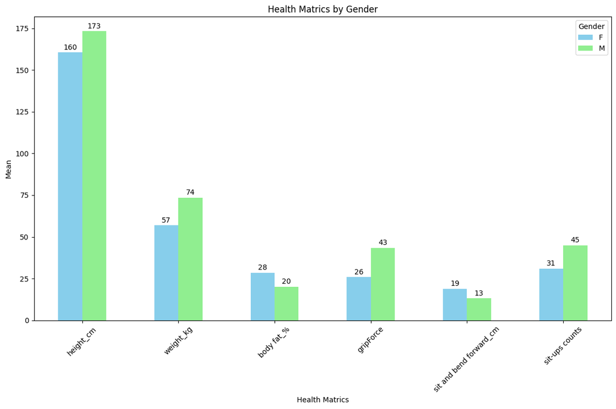

```python
gender_groupby = gender_groupby.T
ax = gender_groupby.plot(kind = 'bar', figsize = (12, 8), color=('skyblue', '#90EE90'))
plt.title("Health Matrics by Gender")
plt.xlabel('Health Matrics')
plt.ylabel('Mean')
plt.xticks(rotation=45)
plt.legend(title='Gender')
for p in ax.patches:
    ax.annotate(format(p.get_height(), '.0f'),
                (p.get_x() + p.get_width() / 2., p.get_height()),
                ha = 'center', va = 'center', #put the center of horizontal and vertical position
                xytext = (0, 7),  # position slightly above the bar
                textcoords = 'offset points'#text should be given as an offset in points relative to a given point.
                )
plt.tight_layout()#adjust the layout to ensure that elements do not overlap
```

- For height, female's mean is 160cm, which is less than male's 173cm.
- For weight, female's mean is 57 kg, which is also less than male's 74 kg.
- For body fat, female's mean is 28%, which is higher than male's 20%.
- For grip force, female's mean is 26, which is significantly less than male's 43.
- For sit and bend forward, female's mean is 19 cm, which is more than male's 13 cm.
- For sit-ups counts, female's mean is 31, which is significantly less than male's 45. In sum, only in sit and bend forward, female performs better than male because female tends to have better flexibility than male. Except flexibility, female overall health matrics perform worse than male.

### 🟢 Q9: Calculating Fitness Scores (18 pt)

In this task, you will assess the fitness levels of individuals using the following three metrics:

- **Grip Force** (a measure of strength)
- **Sit and Bend Forward** (a measure of flexibility)
- **Sit-ups Count** (a measure of strength and endurance of abdominal and hip-flexor muscles)

#### 🔹 Steps:

1. **Calculate Z-scores**:
   - For each of the three metrics, calculate the z-score using the following formula:

$$ z = \frac{x - \mu}{\sigma} $$

Where:

- $x$ is the individual’s score,
- $\mu$ is the mean of the metric, and
- $\sigma$ is the standard deviation of the metric.
2. **Create a Fitness Score**:
   - Create an **overall fitness score** by adding the z-scores of the three metrics together for each individual.
3. **Categorize Fitness Levels**:
   - Use `pd.qcut()` to assign each individual to one of four categories, from the **lowest fitness score** to the **highest fitness score**.
4. **Function Implementation**:
   - Implement one or more functions to perform these calculations and categorization.

#### 🔹 Part A (10 pt):

- Report the **number of individuals** in each of the four fitness score categories.

#### 🔹 Part B (8 pt):

- Compare your fitness categories to the `class` column in the dataset.
- Write a brief summary commenting on:
  - How closely your fitness categories correspond to the `class` column.
  - Any interesting observations or discrepancies between the two.

💡 **Hint**: Remember to include units in your analysis and write-up.

```python
def z_score(dataframe: pd.DataFrame, VaR: str) -> float:
    mean = dataframe[VaR].mean()
    std = dataframe[VaR].std()
    return [(value-mean)/std for value in dataframe[VaR]]
body_perform_normal['z_score_gripforce'] = z_score(body_perform_normal, 'gripForce')
body_perform_normal['z_score_sit_bend'] = z_score(body_perform_normal, 'sit and bend forward_cm')
body_perform_normal['z_score_sit-ups'] = z_score(body_perform_normal, 'sit-ups counts')
body_perform_normal['overall_fitness_scores'] = body_perform_normal['z_score_gripforce']+body_perform_normal['z_score_sit_bend']+body_perform_normal['z_score_sit-ups']
body_perform_normal['fitness_scores_class'] = pd.qcut(body_perform_normal['overall_fitness_scores'], q=4, labels=['Low', 'Medium', 'High', 'Very High'])
print(body_perform_normal['fitness_scores_class'].value_counts())
print(body_perform_normal['class'].value_counts().sort_index())
print(body_perform_normal[['class', 'fitness_scores_class', 'age']].groupby(['class', 'fitness_scores_class']).count())
print(pd.Series(pd.factorize(body_perform_normal['class'])[0]).corr(pd.Series(pd.factorize(body_perform_normal['fitness_scores_class'])[0])))
```

```
fitness_scores_class
Low          3348
Medium       3347
High         3347
Very High    3347
Name: count, dtype: int64
class
A    3347
B    3346
C    3348
D    3348
Name: count, dtype: int64
                             age
class fitness_scores_class
A     Low                     87
      Medium                 637
      High                   974
      Very High             1649
B     Low                    404
      Medium                 937
      High                   984
      Very High             1021
C     Low                    887
      Medium                 968
      High                   981
      Very High              512
D     Low                   1970
      Medium                 805
      High                   408
      Very High              165
0.14511045952718493
```

[output not shown]

#### **Part A**:

- The number of each fitness scores class is roughly equal. There is 3347 in each class.

### 🟢 IMPORTANT: Final Checks

Before you submit your notebook, please ensure that:

- Your complete notebook **runs without errors** from top to bottom.  
  💡 **Tip**: Use the "Run All" feature to quickly check this.

## 📤 Submission Instructions

Submit your completed assignment in both of the following formats:

1. **.IPYNB** (Jupyter Notebook format)
2. **.HTML** (Webpage format)

Upload your files to **Canvas** before the deadline. Be sure to check that you have uploaded the correct files (e.g., don't accidentally submit an in-class notebook as your homework assignment).